# Connect1-Stigma Study: Results

# Overview of results

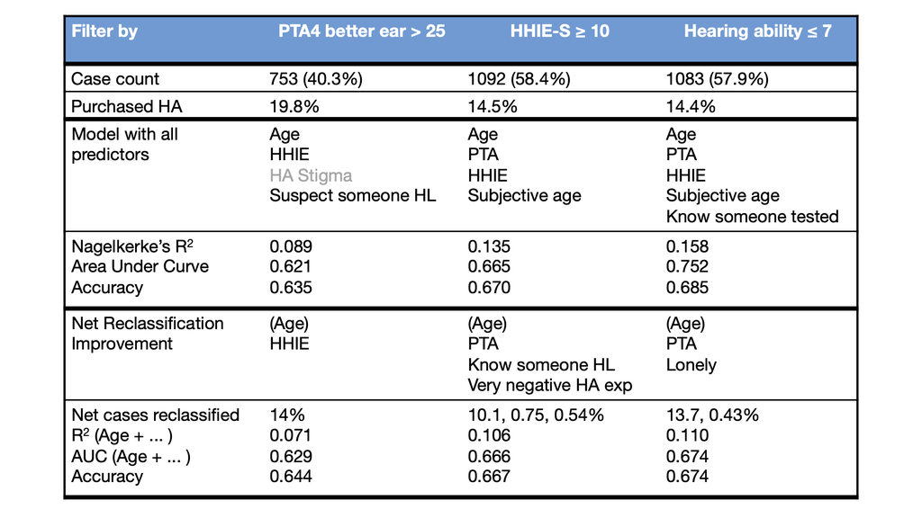

**Load libraries**

# Dataset preparation and descriptive statistics

Read data: Connect_Data_20191025.csv

Remove those with missing age/sex, who are too young, and who have HA experience.

Get some descriptives for the Participants section of the manuscript.

Rename variables, recode variables, and remove rows containing any missing cells for 28 predictors.

Get numbers for Table 1 in manuscript.

# Participant overlap according to three inclusion criteria

## All participants

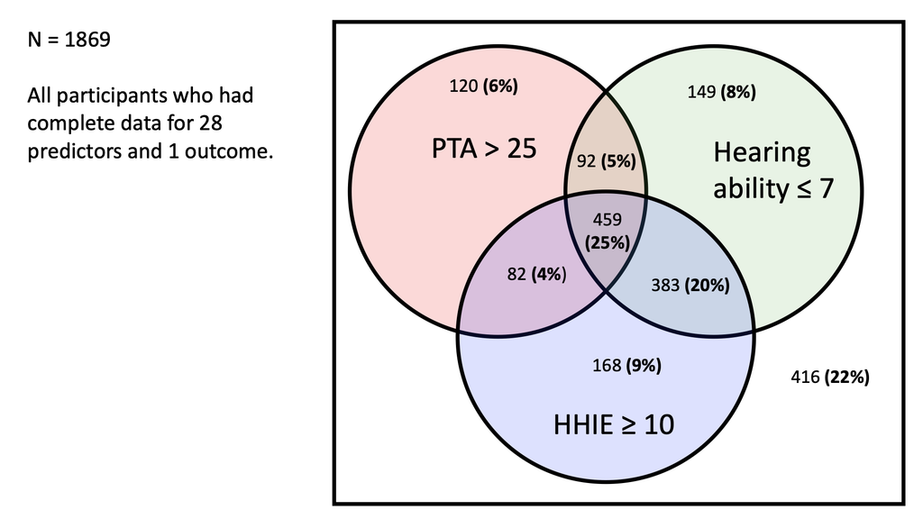

## Only those who purchased HA

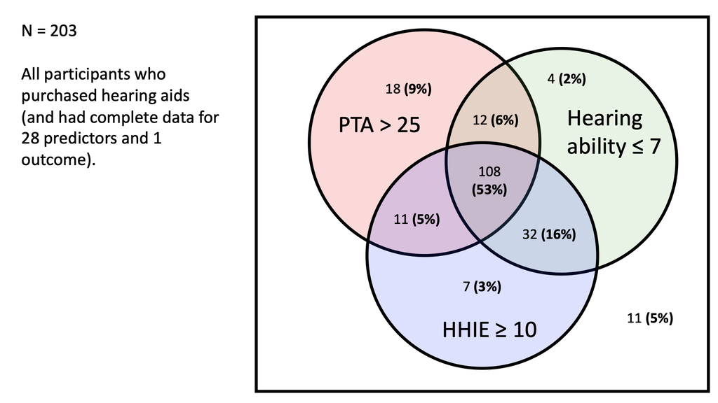

# Correlation among variables

## PTA, HHIE, Hearing Ability

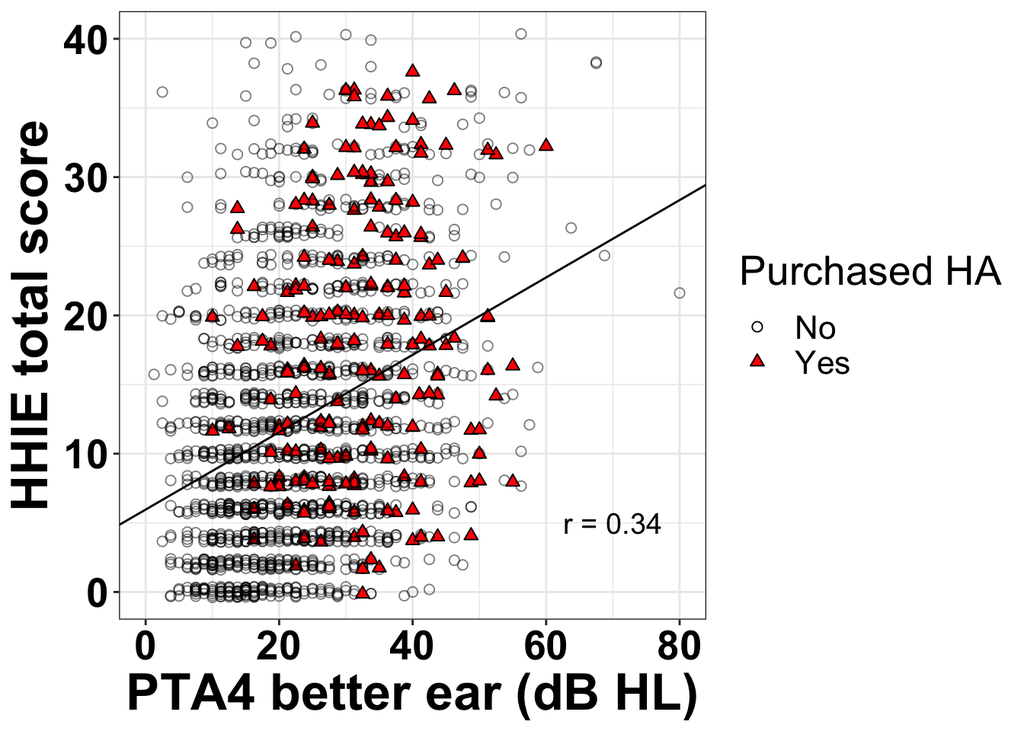

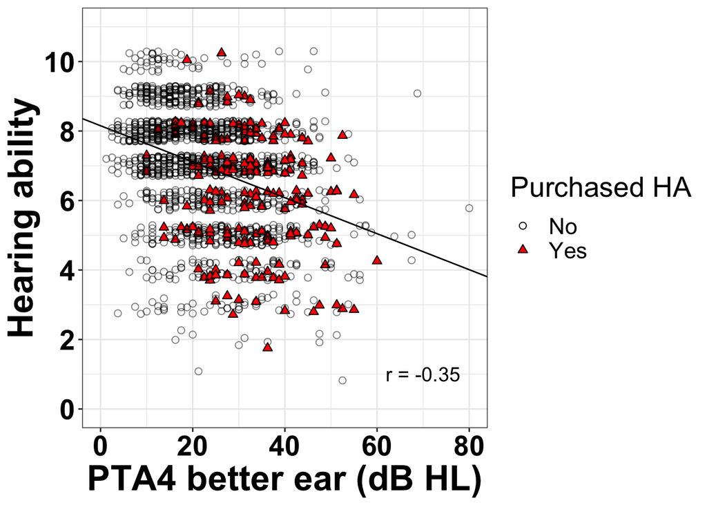

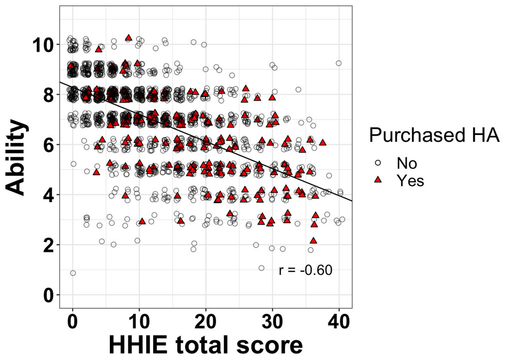

Note: A few participants bought HA despite good PTA and/or HHIE scores.

## Subjective Age, Age Stigma, and HA Stigma

```
##                    d2.Q1 d2.Q2 d2.Q3
## data2.Q1_Corrected 1.00
## data2.Q2_Corrected 0.59  1.00
## data2.Q3_Corrected 0.56  0.65  1.00
```

```
##                    d2.Q4 d2.Q5 d2.Q6 d2.Q7 d2.Q8
## data2.Q4_Corrected  1.00
## data2.Q5_Corrected -0.10  1.00
## data2.Q6_Corrected -0.09  0.49  1.00
## data2.Q7_Corrected -0.06  0.46  0.54  1.00
## data2.Q8_Corrected -0.07  0.45  0.56  0.65  1.00
```

```
##                     d2.Q9 d2.Q10 d2.Q11 d2.Q12
## data2.Q9_Corrected  1.00
## data2.Q10_Corrected 0.70  1.00
## data2.Q11_Corrected 0.69  0.73   1.00
## data2.Q12_Corrected 0.62  0.81   0.73   1.00
```

# PTA

Include only participants with PTA4 > 25 dB HL in the better ear (case count and %).

```
## [1] 753
```

```
## [1] 40.28892
```

Proportion of people who purchased hearing aids

```
##
##        No       Yes
## 0.8021248 0.1978752
```

## PTA: Logistic regression with backwards elimination

The full model contains 28 predictors.

With a backwards elimination procedure, the final model is:

```
##
## Call:
## glm(formula = Purchased_HA ~ Age + HHIE_total + HA_stigma_avg +
##     Soc_Suspect_HL, family = binomial("logit"), data = pta)
##
## Deviance Residuals:
##     Min       1Q   Median       3Q      Max
## -1.4831  -0.6814  -0.5593  -0.4042   2.3437
##
## Coefficients:
##                 Estimate Std. Error z value Pr(>|z|)
## (Intercept)    -5.511323   0.937553  -5.878 4.14e-09 ***
## Age             0.044948   0.010868   4.136 3.53e-05 ***
## HHIE_total      0.045900   0.009955   4.611 4.02e-06 ***
## HA_stigma_avg  -0.163669   0.088638  -1.846   0.0648 .
## Soc_Suspect_HL  0.742241   0.339078   2.189   0.0286 *
## ---
## Signif. codes:  0 '***' 0.001 '**' 0.01 '*' 0.05 '.' 0.1 ' ' 1
##
## (Dispersion parameter for binomial family taken to be 1)
##
##     Null deviance: 749.15  on 752  degrees of freedom
## Residual deviance: 705.28  on 748  degrees of freedom
## AIC: 715.28
##
## Number of Fisher Scoring iterations: 4
```

```
## Pseudo R^2 for Logistic Regression
## Hosmer and Lemeshow 0.05856056
## Cox and Snell 0.05659635
## Nagelkerke 0.08980211
```

```
## AUC [95% CI] for the model 1 :  0.621 [ 0.577  -  0.664 ]
```

```
## Confusion Matrix and Statistics
##
##           Reference
## Prediction   0   1
##          0 389  60
##          1 215  89
##
##                Accuracy : 0.6348
##                  95% CI : (0.5993, 0.6693)
##     No Information Rate : 0.8021
##     P-Value [Acc > NIR] : 1
##
##                   Kappa : 0.1734
##
##  Mcnemar's Test P-Value : <2e-16
##
##             Sensitivity : 0.5973
##             Specificity : 0.6440
##          Pos Pred Value : 0.2928
##          Neg Pred Value : 0.8664
##              Prevalence : 0.1979
##          Detection Rate : 0.1182
##    Detection Prevalence : 0.4037
##       Balanced Accuracy : 0.6207
##
##        'Positive' Class : 1
##
```

## PTA: Net Reclassification Improvement

“Basic” model: Age only

```
##
## Call:
## glm(formula = Purchased_HA ~ Age, family = binomial("logit"),
##     data = pta)
##
## Deviance Residuals:
##     Min       1Q   Median       3Q      Max
## -0.9300  -0.6946  -0.6236  -0.5242   2.0848
##
## Coefficients:
##             Estimate Std. Error z value Pr(>|z|)
## (Intercept) -3.79832    0.74208  -5.118 3.08e-07 ***
## Age          0.03424    0.01039   3.295 0.000985 ***
## ---
## Signif. codes:  0 '***' 0.001 '**' 0.01 '*' 0.05 '.' 0.1 ' ' 1
##
## (Dispersion parameter for binomial family taken to be 1)
##
##     Null deviance: 749.15  on 752  degrees of freedom
## Residual deviance: 738.08  on 751  degrees of freedom
## AIC: 742.08
##
## Number of Fisher Scoring iterations: 4
```

Table of NRI values for 27 “novel” predictors

| Predictor | NRI | p-value |
| --- | --- | --- |
| PTA4_better_ear | -0.000400 | 0.989590 |
| HHIE_total | 0.140000 | 0.003440 |
| Ability | -0.008500 | 0.824360 |
| Sex | 0.048500 | 0.144430 |
| Edu | -0.003200 | 0.850050 |
| Married | 0.018600 | 0.373270 |
| Health | 0.025300 | 0.195670 |
| QoL | 0.031900 | 0.233760 |
| Help_neighbours | 0.000300 | 0.991080 |
| Help_problems | 0.015300 | 0.435690 |
| Concern | 0.016900 | 0.495400 |
| Lonely | 0.000000 | NA |
| Sub_Age_avg | 0.000200 | 0.988380 |
| Age_stigma_avg | -0.018200 | 0.517490 |
| HA_stigma_avg | 0.025500 | 0.488240 |
| Accomp | 0.011700 | 0.579330 |
| Soc_Suspect_HL | 0.054100 | 0.145060 |
| Soc_Know_HL | 0.000000 | NA |
| Soc_Discuss_HL | 0.006700 | 0.699190 |
| Soc_Hearing_test | 0.015100 | 0.422910 |
| Soc_Obtain_HA | 0.006900 | 0.728710 |
| Soc_Sometimes_use | 0.003700 | 0.801540 |
| Soc_Regular_use | 0.005100 | 0.781160 |
| Soc_Very_positive | -0.001500 | 0.968770 |
| Soc_Somewhat_positive | -0.008200 | 0.324350 |
| Soc_Somewhat_negative | 0.000300 | 0.983420 |
| Soc_Very_negative | -0.009700 | 0.471530 |

## PTA: Evaluation of regression model containing NRI predictors

```
##
## Call:
## glm(formula = Purchased_HA ~ Age + HHIE_total, family = binomial("logit"),
##     data = pta)
##
## Deviance Residuals:
##     Min       1Q   Median       3Q      Max
## -1.4084  -0.6776  -0.5749  -0.4521   2.3276
##
## Coefficients:
##              Estimate Std. Error z value Pr(>|z|)
## (Intercept) -5.402297   0.826588  -6.536 6.33e-11 ***
## Age          0.045903   0.010755   4.268 1.97e-05 ***
## HHIE_total   0.047276   0.009866   4.792 1.65e-06 ***
## ---
## Signif. codes:  0 '***' 0.001 '**' 0.01 '*' 0.05 '.' 0.1 ' ' 1
##
## (Dispersion parameter for binomial family taken to be 1)
##
##     Null deviance: 749.15  on 752  degrees of freedom
## Residual deviance: 714.77  on 750  degrees of freedom
## AIC: 720.77
##
## Number of Fisher Scoring iterations: 4
```

```
## (Intercept)         Age  HHIE_total
## 0.004506219 1.046973096 1.048411035
```

```
##                      OR        2.5 %     97.5 %
## (Intercept) 0.004506219 0.0008656503 0.02221431
## Age         1.046973096 1.0253296202 1.06954803
## HHIE_total  1.048411035 1.0284401784 1.06905874
```

```
## Pseudo R^2 for Logistic Regression
## Hosmer and Lemeshow 0.04588639
## Cox and Snell 0.04462533
## Nagelkerke 0.07080754
```

```
## AUC [95% CI] for the model 1 :  0.629 [ 0.585  -  0.673 ]
```

```
## Confusion Matrix and Statistics
##
##           Reference
## Prediction   0   1
##          0 395  59
##          1 209  90
##
##                Accuracy : 0.6441
##                  95% CI : (0.6087, 0.6783)
##     No Information Rate : 0.8021
##     P-Value [Acc > NIR] : 1
##
##                   Kappa : 0.1871
##
##  Mcnemar's Test P-Value : <2e-16
##
##             Sensitivity : 0.6040
##             Specificity : 0.6540
##          Pos Pred Value : 0.3010
##          Neg Pred Value : 0.8700
##              Prevalence : 0.1979
##          Detection Rate : 0.1195
##    Detection Prevalence : 0.3971
##       Balanced Accuracy : 0.6290
##
##        'Positive' Class : 1
##
```

# HHIE-S

Include only participants with HHIE-S scores ≥ 10 (case count and %).

```
## [1] 1092
```

```
## [1] 58.42697
```

Proportion of people who purchased hearing aids

```
##
##        No       Yes
## 0.8553114 0.1446886
```

## HHIE-S: Logistic regression with backwards elimination

The full model contains 28 predictors.

With a backwards elimination procedure, the final model is:

```
##
## Call:
## glm(formula = Purchased_HA ~ Age + PTA4_better_ear + HHIE_total +
##     Sub_Age_avg, family = binomial("logit"), data = hhie)
##
## Deviance Residuals:
##     Min       1Q   Median       3Q      Max
## -1.5555  -0.5736  -0.4370  -0.3059   2.5471
##
## Coefficients:
##                  Estimate Std. Error z value Pr(>|z|)
## (Intercept)     -5.932949   0.805059  -7.370 1.71e-13 ***
## Age              0.044830   0.010992   4.078 4.53e-05 ***
## PTA4_better_ear  0.032391   0.008548   3.789 0.000151 ***
## HHIE_total       0.047018   0.011955   3.933 8.39e-05 ***
## Sub_Age_avg     -0.234326   0.098336  -2.383 0.017177 *
## ---
## Signif. codes:  0 '***' 0.001 '**' 0.01 '*' 0.05 '.' 0.1 ' ' 1
##
## (Dispersion parameter for binomial family taken to be 1)
##
##     Null deviance: 902.83  on 1091  degrees of freedom
## Residual deviance: 816.89  on 1087  degrees of freedom
## AIC: 826.89
##
## Number of Fisher Scoring iterations: 5
```

```
## Pseudo R^2 for Logistic Regression
## Hosmer and Lemeshow 0.0951944
## Cox and Snell 0.07568627
## Nagelkerke 0.134544
```

```
## AUC [95% CI] for the model 1 :  0.665 [ 0.625  -  0.705 ]
```

```
## Confusion Matrix and Statistics
##
##           Reference
## Prediction   0   1
##          0 628  54
##          1 306 104
##
##                Accuracy : 0.6703
##                  95% CI : (0.6416, 0.6982)
##     No Information Rate : 0.8553
##     P-Value [Acc > NIR] : 1
##
##                   Kappa : 0.1989
##
##  Mcnemar's Test P-Value : <2e-16
##
##             Sensitivity : 0.65823
##             Specificity : 0.67238
##          Pos Pred Value : 0.25366
##          Neg Pred Value : 0.92082
##              Prevalence : 0.14469
##          Detection Rate : 0.09524
##    Detection Prevalence : 0.37546
##       Balanced Accuracy : 0.66530
##
##        'Positive' Class : 1
##
```

## HHIE-S: Net Reclassification Improvement

“Basic” model: Age only

```
##
## Call:
## glm(formula = Purchased_HA ~ Age, family = binomial("logit"),
##     data = hhie)
##
## Deviance Residuals:
##     Min       1Q   Median       3Q      Max
## -1.1141  -0.5984  -0.4757  -0.3872   2.3667
##
## Coefficients:
##              Estimate Std. Error z value Pr(>|z|)
## (Intercept) -5.879683   0.668624  -8.794  < 2e-16 ***
## Age          0.061601   0.009717   6.340  2.3e-10 ***
## ---
## Signif. codes:  0 '***' 0.001 '**' 0.01 '*' 0.05 '.' 0.1 ' ' 1
##
## (Dispersion parameter for binomial family taken to be 1)
##
##     Null deviance: 902.83  on 1091  degrees of freedom
## Residual deviance: 861.58  on 1090  degrees of freedom
## AIC: 865.58
##
## Number of Fisher Scoring iterations: 5
```

Table of NRI values for 27 “novel” predictors

| Predictor | NRI | p-value |
| --- | --- | --- |
| PTA4_better_ear | 0.1009 | 0.01164 |
| HHIE_total | 0.0702 | 0.07463 |
| Ability | -0.0019 | 0.95844 |
| Sex | -0.0054 | 0.6254 |
| Edu | -0.0071 | 0.6698 |
| Married | 0.0055 | 0.5760 |
| Health | 0.0118 | 0.4871 |
| QoL | -0.0043 | 0.7918 |
| Help_neighbours | 0.0000 | NA |
| Help_problems | -0.0168 | 0.2221 |
| Concern | 0.0000 | NA |
| Lonely | 0.0000 | NA |
| Sub_Age_avg | 0.0305 | 0.2274 |
| Age_stigma_avg | -0.0168 | 0.2192 |
| HA_stigma_avg | -0.0181 | 0.4279 |
| Accomp | 0.0061 | 0.5924 |
| Soc_Suspect_HL | -0.0255 | 0.2464 |
| Soc_Know_HL | 0.0075 | 0.0079 |
| Soc_Discuss_HL | 0.0000 | NA |
| Soc_Hearing_test | -0.0211 | 0.3117 |
| Soc_Obtain_HA | -0.0020 | 0.8374 |
| Soc_Sometimes_use | 0.0120 | 0.2425 |
| Soc_Regular_use | 0.0076 | 0.3039 |
| Soc_Very_positive | -0.0097 | 0.7279 |
| Soc_Somewhat_positive | 0.0003 | 0.9807 |
| Soc_Somewhat_negative | 0.0087 | 0.2455 |
| Soc_Very_negative | 0.0054 | 0.0250 |

## HHIE: Evaluation of regression model containing NRI predictors

```
##
## Call:
## glm(formula = Purchased_HA ~ Age + PTA4_better_ear + Soc_Know_HL +
##     Soc_Very_negative, family = binomial("logit"), data = hhie)
##
## Deviance Residuals:
##     Min       1Q   Median       3Q      Max
## -1.4139  -0.5795  -0.4523  -0.3405   2.5200
##
## Coefficients:
##                    Estimate Std. Error z value Pr(>|z|)
## (Intercept)       -5.634437   0.711119  -7.923 2.31e-15 ***
## Age                0.037908   0.010774   3.518 0.000434 ***
## PTA4_better_ear    0.041687   0.008208   5.079 3.80e-07 ***
## Soc_Know_HL        0.143634   0.253488   0.567 0.570966
## Soc_Very_negative  0.030300   0.233959   0.130 0.896955
## ---
## Signif. codes:  0 '***' 0.001 '**' 0.01 '*' 0.05 '.' 0.1 ' ' 1
##
## (Dispersion parameter for binomial family taken to be 1)
##
##     Null deviance: 902.83  on 1091  degrees of freedom
## Residual deviance: 835.45  on 1087  degrees of freedom
## AIC: 845.45
##
## Number of Fisher Scoring iterations: 5
```

```
##       (Intercept)               Age   PTA4_better_ear       Soc_Know_HL
##       0.003572688       1.038635684       1.042568054       1.154461047
## Soc_Very_negative
##       1.030763369
```

```
##                            OR       2.5 %     97.5 %
## (Intercept)       0.003572688 0.000865588 0.01410872
## Age               1.038635684 1.017024609 1.06095695
## PTA4_better_ear   1.042568054 1.025991588 1.05961411
## Soc_Know_HL       1.154461047 0.714235279 1.93674721
## Soc_Very_negative 1.030763369 0.642174381 1.61122277
```

```
## Pseudo R^2 for Logistic Regression
## Hosmer and Lemeshow 0.0746346
## Cox and Snell 0.05984032
## Nagelkerke 0.1063753
```

```
## AUC [95% CI] for the model 1 :  0.666 [ 0.626  -  0.706 ]
```

```
## Confusion Matrix and Statistics
##
##           Reference
## Prediction   0   1
##          0 623  53
##          1 311 105
##
##                Accuracy : 0.6667
##                  95% CI : (0.6378, 0.6946)
##     No Information Rate : 0.8553
##     P-Value [Acc > NIR] : 1
##
##                   Kappa : 0.1976
##
##  Mcnemar's Test P-Value : <2e-16
##
##             Sensitivity : 0.66456
##             Specificity : 0.66702
##          Pos Pred Value : 0.25240
##          Neg Pred Value : 0.92160
##              Prevalence : 0.14469
##          Detection Rate : 0.09615
##    Detection Prevalence : 0.38095
##       Balanced Accuracy : 0.66579
##
##        'Positive' Class : 1
##
```

# Hearing ability (scale of 1 to 10)

Include only participants with self-reported overall hearing ability scores ≤ 7 (case count and %).

```
## [1] 1083
```

```
## [1] 57.94543
```

Proportion of people who purchased hearing aids

```
##
##        No       Yes
## 0.8559557 0.1440443
```

## Hearing ability: Logistic regression with backwards elimination

The full model contains 28 predictors.

With a backwards elimination procedure, the final model is:

```
##
## Call:
## glm(formula = Purchased_HA ~ Age + PTA4_better_ear + HHIE_total +
##     Sub_Age_avg + Soc_Hearing_test, family = binomial("logit"),
##     data = ab)
##
## Deviance Residuals:
##     Min       1Q   Median       3Q      Max
## -1.6092  -0.5742  -0.4207  -0.2791   2.5105
##
## Coefficients:
##                   Estimate Std. Error z value Pr(>|z|)
## (Intercept)      -6.814746   0.849144  -8.025 1.01e-15 ***
## Age               0.051377   0.011425   4.497 6.89e-06 ***
## PTA4_better_ear   0.032199   0.009005   3.576 0.000349 ***
## HHIE_total        0.049701   0.010506   4.731 2.24e-06 ***
## Sub_Age_avg      -0.204719   0.100110  -2.045 0.040860 *
## Soc_Hearing_test  0.508986   0.204568   2.488 0.012843 *
## ---
## Signif. codes:  0 '***' 0.001 '**' 0.01 '*' 0.05 '.' 0.1 ' ' 1
##
## (Dispersion parameter for binomial family taken to be 1)
##
##     Null deviance: 892.91  on 1082  degrees of freedom
## Residual deviance: 792.22  on 1077  degrees of freedom
## AIC: 804.22
##
## Number of Fisher Scoring iterations: 5
```

```
## Pseudo R^2 for Logistic Regression
## Hosmer and Lemeshow 0.1127669
## Cox and Snell 0.08878241
## Nagelkerke 0.1581066
```

```
## AUC [95% CI] for the model 1 :  0.752 [ 0.714  -  0.79 ]
```

```
## Confusion Matrix and Statistics
##
##           Reference
## Prediction   0   1
##          0 633  47
##          1 294 109
##
##                Accuracy : 0.6851
##                  95% CI : (0.6565, 0.7127)
##     No Information Rate : 0.856
##     P-Value [Acc > NIR] : 1
##
##                   Kappa : 0.2301
##
##  Mcnemar's Test P-Value : <2e-16
##
##             Sensitivity : 0.6987
##             Specificity : 0.6828
##          Pos Pred Value : 0.2705
##          Neg Pred Value : 0.9309
##              Prevalence : 0.1440
##          Detection Rate : 0.1006
##    Detection Prevalence : 0.3721
##       Balanced Accuracy : 0.6908
##
##        'Positive' Class : 1
##
```

## Hearing ability: Net Reclassification Improvement

“Basic” model: Age only

```
##
## Call:
## glm(formula = Purchased_HA ~ Age, family = binomial("logit"),
##     data = ab)
##
## Deviance Residuals:
##     Min       1Q   Median       3Q      Max
## -1.1226  -0.5929  -0.4824  -0.3788   2.3867
##
## Coefficients:
##              Estimate Std. Error z value Pr(>|z|)
## (Intercept) -6.016154   0.679286  -8.857  < 2e-16 ***
## Age          0.063289   0.009823   6.443 1.17e-10 ***
## ---
## Signif. codes:  0 '***' 0.001 '**' 0.01 '*' 0.05 '.' 0.1 ' ' 1
##
## (Dispersion parameter for binomial family taken to be 1)
##
##     Null deviance: 892.91  on 1082  degrees of freedom
## Residual deviance: 850.06  on 1081  degrees of freedom
## AIC: 854.06
##
## Number of Fisher Scoring iterations: 5
```

Table of NRI values for 27 “novel” predictors

| Predictor | NRI | p-value |
| --- | --- | --- |
| PTA4_better_ear | 0.1374 | 0.00064 |
| HHIE_total | 0.0679 | 0.09917 |
| Ability | -0.0382 | 0.2205 |
| Sex | 0.0023 | 0.8450 |
| Edu | -0.0010 | 0.9464 |
| Married | 0.0131 | 0.2092 |
| Health | -0.0032 | 0.8333 |
| QoL | 0.0022 | 0.7537 |
| Help_neighbours | -0.0160 | 0.4712 |
| Help_problems | 0.0022 | 0.7537 |
| Concern | -0.0010 | 0.9353 |
| Lonely | 0.0043 | 0.0450 |
| Sub_Age_avg | 0.0258 | 0.2611 |
| Age_stigma_avg | -0.0255 | 0.1120 |
| HA_stigma_avg | -0.0041 | 0.8639 |
| Accomp | 0.0034 | 0.8495 |
| Soc_Suspect_HL | -0.0050 | 0.7803 |
| Soc_Know_HL | 0.0076 | 0.3079 |
| Soc_Discuss_HL | 0.0108 | 0.1582 |
| Soc_Hearing_test | 0.0075 | 0.7954 |
| Soc_Obtain_HA | -0.0011 | 0.9567 |
| Soc_Sometimes_use | -0.0159 | 0.2803 |
| Soc_Regular_use | -0.0063 | 0.7725 |
| Soc_Very_positive | 0.0034 | 0.9088 |
| Soc_Somewhat_positive | 0.0141 | 0.0748 |
| Soc_Somewhat_negative | 0.0067 | 0.5843 |
| Soc_Very_negative | -0.0083 | 0.5967 |

## Hearing ability: Evaluation of regression model containing NRI predictors

```
##
## Call:
## glm(formula = Purchased_HA ~ Age + PTA4_better_ear + Lonely,
##     family = binomial("logit"), data = ab)
##
## Deviance Residuals:
##     Min       1Q   Median       3Q      Max
## -1.3492  -0.5768  -0.4440  -0.3372   2.4931
##
## Coefficients:
##                  Estimate Std. Error z value Pr(>|z|)
## (Intercept)     -5.500788   0.715602  -7.687 1.51e-14 ***
## Age              0.038041   0.010795   3.524 0.000425 ***
## PTA4_better_ear  0.043578   0.008478   5.140 2.75e-07 ***
## Lonely          -0.089275   0.180943  -0.493 0.621740
## ---
## Signif. codes:  0 '***' 0.001 '**' 0.01 '*' 0.05 '.' 0.1 ' ' 1
##
## (Dispersion parameter for binomial family taken to be 1)
##
##     Null deviance: 892.91  on 1082  degrees of freedom
## Residual deviance: 823.57  on 1079  degrees of freedom
## AIC: 831.57
##
## Number of Fisher Scoring iterations: 5
```

```
##     (Intercept)             Age PTA4_better_ear          Lonely
##     0.004083552     1.038773888     1.044541750     0.914594326
```

```
##                          OR        2.5 %     97.5 %
## (Intercept)     0.004083552 0.0009834612 0.01631875
## Age             1.038773888 1.0171460887 1.06117344
## PTA4_better_ear 1.044541750 1.0273903091 1.06219013
## Lonely          0.914594326 0.6283674118 1.28130054
```

```
## Pseudo R^2 for Logistic Regression
## Hosmer and Lemeshow 0.07765844
## Cox and Snell 0.06202077
## Nagelkerke 0.1104486
```

```
## AUC [95% CI] for the model 1 :  0.674 [ 0.634  -  0.713 ]
```

```
## Confusion Matrix and Statistics
##
##           Reference
## Prediction   0   1
##          0 625  51
##          1 302 105
##
##                Accuracy : 0.6741
##                  95% CI : (0.6452, 0.7019)
##     No Information Rate : 0.856
##     P-Value [Acc > NIR] : 1
##
##                   Kappa : 0.2081
##
##  Mcnemar's Test P-Value : <2e-16
##
##             Sensitivity : 0.67308
##             Specificity : 0.67422
##          Pos Pred Value : 0.25799
##          Neg Pred Value : 0.92456
##              Prevalence : 0.14404
##          Detection Rate : 0.09695
##    Detection Prevalence : 0.37581
##       Balanced Accuracy : 0.67365
##
##        'Positive' Class : 1
##
```